# Life in BRC

## Camp Location, Camp Size, Family, Minors, and RV/Camper Use

## Camp Location

### Camp Location Preassignment

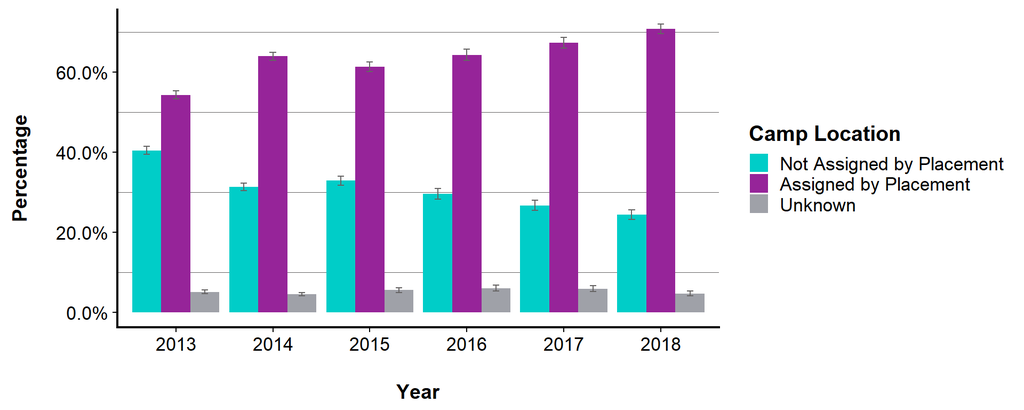

Error bars indicate the upper and lower bounds of the 95% confidence intervals.

|  | 2013 Percent | 2013 MoE +/- % |  | 2014 Percent | 2014 MoE +/- % |  | 2015 Percent | 2015 MoE +/- % |  | 2016 Percent | 2016 MoE +/- % |  | 2017 Percent | 2017 MoE +/- % |  | 2018 Percent | 2018 MoE +/- % |
| --- | --- | --- | --- | --- | --- | --- | --- | --- | --- | --- | --- | --- | --- | --- | --- | --- | --- |
| Not Assigned by Placement | 40.5 | 1.0 |  | 31.4 | 1.0 |  | 33.0 | 1.2 |  | 29.6 | 1.4 |  | 26.7 | 1.2 |  | 24.4 | 1.2 |
| Assigned by Placement | 54.3 | 1.0 |  | 64.0 | 1.0 |  | 61.4 | 1.2 |  | 64.3 | 1.4 |  | 67.4 | 1.4 |  | 70.8 | 1.2 |
| Unknown | 5.1 | 0.4 |  | 4.6 | 0.4 |  | 5.6 | 0.6 |  | 6.1 | 0.8 |  | 5.9 | 0.8 |  | 4.7 | 0.6 |

## Camp Location

### Camp Location Factors*

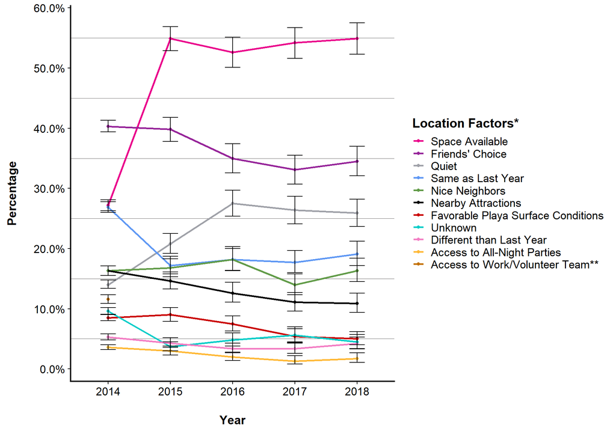

Error bars indicate the upper and lower bounds of the 95% confidence intervals.

* Participants selected up to three option(s) that applied. Data in the plot above and table below represent participants who indicated a camp location that was *not* pre-assigned by the Buring Man Placement Team.  
** "Access to work/volunteer group" was included as an option in the 2014 online survey, but not in later years' surveys.

|  | 2014 Percent | 2014 MoE +/- % |  | 2015 Percent | 2015 MoE +/- % |  | 2016 Percent | 2016 MoE +/- % |  | 2017 Percent | 2017 MoE +/- % |  | 2018 Percent | 2018 MoE +/- % |
| --- | --- | --- | --- | --- | --- | --- | --- | --- | --- | --- | --- | --- | --- | --- |
| Space Available | 27.2 | 1.0 |  | 54.9 | 2.0 |  | 52.6 | 2.5 |  | 54.2 | 2.5 |  | 54.9 | 2.5 |
| Friends’ Choice | 40.3 | 1.0 |  | 39.8 | 2.0 |  | 35.0 | 2.4 |  | 33.1 | 2.4 |  | 34.5 | 2.5 |
| Quiet | 14.0 | 0.8 |  | 20.8 | 1.6 |  | 27.5 | 2.2 |  | 26.4 | 2.4 |  | 25.9 | 2.4 |
| Same as Last Year | 26.9 | 1.0 |  | 17.2 | 1.6 |  | 18.2 | 1.8 |  | 17.7 | 2.0 |  | 19.1 | 2.0 |
| Nice Neighbors | 16.3 | 0.8 |  | 16.8 | 1.6 |  | 18.2 | 2.0 |  | 14.0 | 1.8 |  | 16.3 | 2.0 |
| Nearby Attractions | 16.3 | 0.8 |  | 14.6 | 1.4 |  | 12.6 | 1.8 |  | 11.1 | 1.6 |  | 10.9 | 1.6 |
| Favorable Playa Surface Conditions | 8.5 | 0.6 |  | 9.0 | 1.2 |  | 7.5 | 1.2 |  | 5.4 | 1.2 |  | 5.0 | 1.2 |
| Unknown | 9.6 | 0.6 |  | 3.7 | 0.8 |  | 4.8 | 1.2 |  | 5.6 | 1.2 |  | 4.5 | 1.2 |
| Different than Last Year | 5.3 | 0.4 |  | 4.3 | 0.8 |  | 3.4 | 0.8 |  | 3.4 | 1.0 |  | 4.2 | 1.0 |
| Access to All-Night Parties | 3.6 | 0.4 |  | 3.0 | 0.8 |  | 2.0 | 0.8 |  | 1.3 | 0.6 |  | 1.7 | 0.8 |
| Access to Work/Volunteer Team** | 11.6 | 0.8 |  | NA | NA |  | NA | NA |  | NA | NA |  | NA | NA |

## Camp Size

### Total Number of People in Camp*

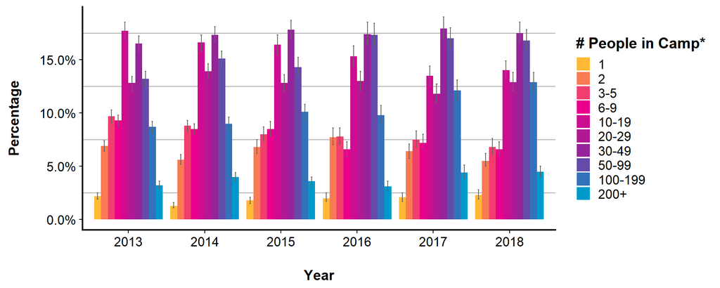

Error bars indicate the upper and lower bounds of the 95% confidence intervals.

* The exact wording of the question in the online survey was,"How many people were in your camp (total, including you)?"

|  | 2013 Percent | 2013 MoE +/- % |  | 2014 Percent | 2014 MoE +/- % |  | 2015 Percent | 2015 MoE +/- % |  | 2016 Percent | 2016 MoE +/- % |  | 2017 Percent | 2017 MoE +/- % |  | 2018 Percent | 2018 MoE +/- % |
| --- | --- | --- | --- | --- | --- | --- | --- | --- | --- | --- | --- | --- | --- | --- | --- | --- | --- |
| 1 | 2.2 | 0.2 |  | 1.3 | 0.2 |  | 1.8 | 0.4 |  | 2.0 | 0.4 |  | 2.1 | 0.4 |  | 2.3 | 0.4 |
| 2 | 6.9 | 0.6 |  | 5.6 | 0.4 |  | 6.8 | 0.6 |  | 7.7 | 0.8 |  | 6.4 | 0.6 |  | 5.5 | 0.6 |
| 3-5 | 9.7 | 0.6 |  | 8.8 | 0.6 |  | 8.0 | 0.6 |  | 7.8 | 0.8 |  | 7.5 | 0.8 |  | 6.8 | 0.8 |
| 6-9 | 9.3 | 0.6 |  | 8.5 | 0.6 |  | 8.5 | 0.8 |  | 6.6 | 0.8 |  | 7.2 | 0.8 |  | 6.6 | 0.6 |
| 10-19 | 17.7 | 0.8 |  | 16.6 | 0.8 |  | 16.4 | 1.0 |  | 15.3 | 1.0 |  | 13.5 | 1.0 |  | 14.0 | 1.0 |
| 20-29 | 12.8 | 0.6 |  | 13.9 | 0.6 |  | 12.8 | 0.8 |  | 13.0 | 1.0 |  | 11.8 | 0.8 |  | 12.9 | 0.8 |
| 30-49 | 16.5 | 0.8 |  | 17.3 | 0.8 |  | 17.8 | 1.0 |  | 17.4 | 1.0 |  | 17.9 | 1.0 |  | 17.5 | 1.0 |
| 50-99 | 13.2 | 0.6 |  | 15.1 | 0.8 |  | 14.3 | 0.8 |  | 17.3 | 1.0 |  | 17.0 | 1.0 |  | 16.8 | 1.0 |
| 100-199 | 8.7 | 0.6 |  | 9.0 | 0.6 |  | 10.1 | 0.8 |  | 9.8 | 0.8 |  | 12.1 | 1.0 |  | 12.9 | 0.8 |
| 200+ | 3.2 | 0.4 |  | 4.0 | 0.4 |  | 3.6 | 0.4 |  | 3.1 | 0.4 |  | 4.4 | 0.6 |  | 4.5 | 0.6 |

## Family in Black Rock City

### Total Number of Family Members in BRC This Year*

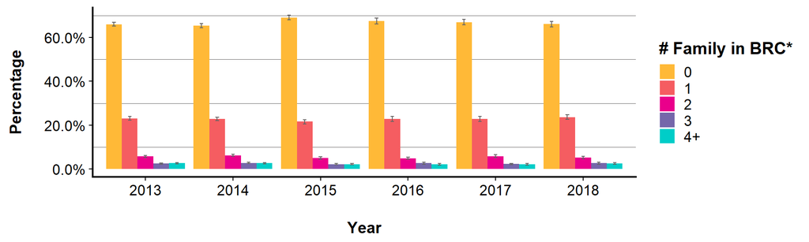

Error bars indicate the upper and lower bounds of the 95% confidence intervals.

* The exact wording of the question in the online survey was,"How many of your family members were in Black Rock City this year? (e.g. relatives, spouses, offspring, in-laws)"

|  | 2013 Percent | 2013 MoE +/- % |  | 2014 Percent | 2014 MoE +/- % |  | 2015 Percent | 2015 MoE +/- % |  | 2016 Percent | 2016 MoE +/- % |  | 2017 Percent | 2017 MoE +/- % |  | 2018 Percent | 2018 MoE +/- % |
| --- | --- | --- | --- | --- | --- | --- | --- | --- | --- | --- | --- | --- | --- | --- | --- | --- | --- |
| 0 | 66.0 | 1.0 |  | 65.4 | 1.0 |  | 69.1 | 1.2 |  | 67.5 | 1.4 |  | 66.9 | 1.2 |  | 66.1 | 1.2 |
| 1 | 23.1 | 0.8 |  | 22.9 | 0.8 |  | 21.6 | 1.0 |  | 22.8 | 1.2 |  | 22.8 | 1.2 |  | 23.7 | 1.2 |
| 2 | 5.7 | 0.4 |  | 6.2 | 0.6 |  | 5.0 | 0.6 |  | 4.9 | 0.6 |  | 5.8 | 0.6 |  | 5.2 | 0.6 |
| 3 | 2.5 | 0.4 |  | 2.8 | 0.4 |  | 2.2 | 0.4 |  | 2.7 | 0.4 |  | 2.3 | 0.4 |  | 2.7 | 0.4 |
| 4+ | 2.7 | 0.4 |  | 2.7 | 0.4 |  | 2.2 | 0.4 |  | 2.2 | 0.4 |  | 2.2 | 0.4 |  | 2.5 | 0.4 |

## Minors in Black Rock City

### Perspectives on Bringing Minors to Black Rock City

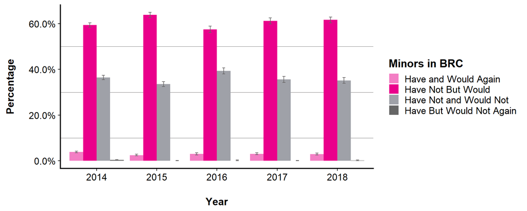

Error bars indicate the upper and lower bounds of the 95% confidence intervals.

|  | 2014 Percent | 2014 MoE +/- % |  | 2015 Percent | 2015 MoE +/- % |  | 2016 Percent | 2016 MoE +/- % |  | 2017 Percent | 2017 MoE +/- % |  | 2018 Percent | 2018 MoE +/- % |
| --- | --- | --- | --- | --- | --- | --- | --- | --- | --- | --- | --- | --- | --- | --- |
| Have and Would Again | 3.9 | 0.4 |  | 2.5 | 0.4 |  | 3.1 | 0.4 |  | 3.1 | 0.4 |  | 3.0 | 0.4 |
| Have Not But Would | 59.4 | 1.0 |  | 63.8 | 1.2 |  | 57.5 | 1.4 |  | 61.2 | 1.4 |  | 61.7 | 1.2 |
| Have Not and Would Not | 36.4 | 1.0 |  | 33.6 | 1.2 |  | 39.3 | 1.4 |  | 35.6 | 1.4 |  | 35.1 | 1.2 |
| Have But Would Not Again | 0.4 | 0.2 |  | 0.1 | 0.0 |  | 0.1 | 0.2 |  | 0.1 | 0.0 |  | 0.2 | 0.2 |

## Minors in Black Rock City

### Perspectives on Restricting Minors from Black Rock City

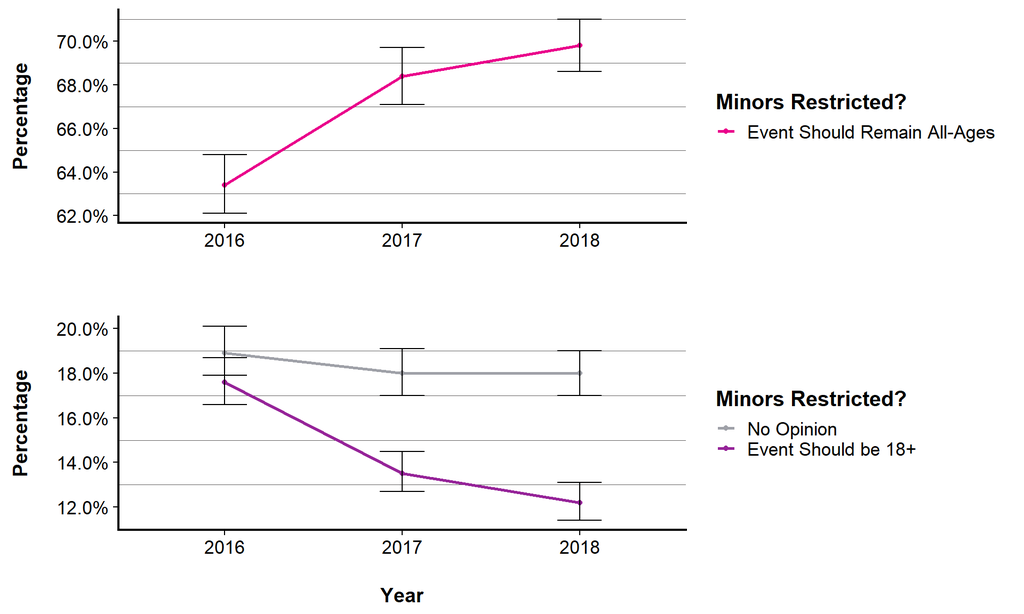

Error bars indicate the upper and lower bounds of the 95% confidence intervals.

|  | 2016 Percent | 2016 MoE +/- % |  | 2017 Percent | 2017 MoE +/- % |  | 2018 Percent | 2018 MoE +/- % |
| --- | --- | --- | --- | --- | --- | --- | --- | --- |
| Event Should Remain All-Ages | 63.4 | 1.4 |  | 68.4 | 1.2 |  | 69.8 | 1.2 |
| No Opinion | 18.9 | 1.2 |  | 18.0 | 1.0 |  | 18.0 | 1.0 |
| Event Should be 18+ | 17.6 | 1.0 |  | 13.5 | 1.0 |  | 12.2 | 0.8 |

## RV/Camper Use

### Participant Indication of Camper/RV Use in BRC

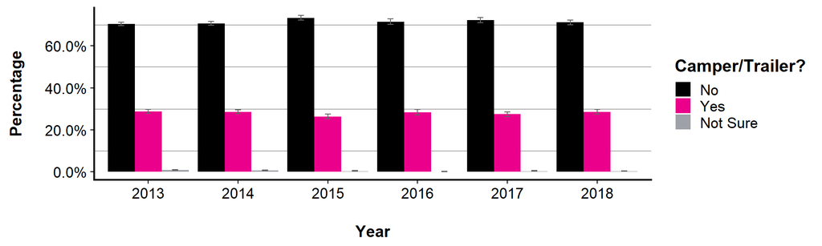

Error bars indicate the upper and lower bounds of the 95% confidence intervals.

|  | 2013 Percent | 2013 MoE +/- % |  | 2014 Percent | 2014 MoE +/- % |  | 2015 Percent | 2015 MoE +/- % |  | 2016 Percent | 2016 MoE +/- % |  | 2017 Percent | 2017 MoE +/- % |  | 2018 Percent | 2018 MoE +/- % |
| --- | --- | --- | --- | --- | --- | --- | --- | --- | --- | --- | --- | --- | --- | --- | --- | --- | --- |
| No | 70.4 | 1.0 |  | 70.7 | 1.0 |  | 73.3 | 1.0 |  | 71.5 | 1.2 |  | 72.3 | 1.2 |  | 71.2 | 1.2 |
| Yes | 28.8 | 1.0 |  | 28.6 | 1.0 |  | 26.3 | 1.0 |  | 28.4 | 1.2 |  | 27.4 | 1.2 |  | 28.6 | 1.2 |
| Not Sure | 0.8 | 0.2 |  | 0.7 | 0.2 |  | 0.3 | 0.2 |  | 0.1 | 0.0 |  | 0.3 | 0.2 |  | 0.3 | 0.2 |

## RV/Camper Use

### Participant Indication of Camper/RV Service in BRC*

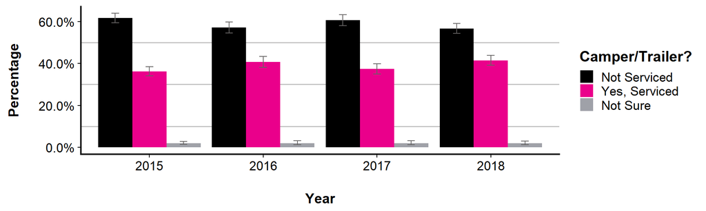

Error bars indicate the upper and lower bounds of the 95% confidence intervals.

* Data presented in the plot above and table below represent responses from participants indicating RV/trailer use during Burning Man in a given year.

|  | 2015 Percent | 2015 MoE +/- % |  | 2016 Percent | 2016 MoE +/- % |  | 2017 Percent | 2017 MoE +/- % |  | 2018 Percent | 2018 MoE +/- % |
| --- | --- | --- | --- | --- | --- | --- | --- | --- | --- | --- | --- |
| Not Serviced | 61.7 | 2.2 |  | 57.2 | 2.5 |  | 60.7 | 2.5 |  | 56.6 | 2.4 |
| Yes, Serviced | 36.2 | 2.2 |  | 40.8 | 2.5 |  | 37.4 | 2.5 |  | 41.4 | 2.4 |
| Not Sure | 2.0 | 0.6 |  | 2.0 | 1.0 |  | 2.0 | 1.0 |  | 2.0 | 0.8 |

## RV/Camper Use

### Number of Adults in RV/Camper*

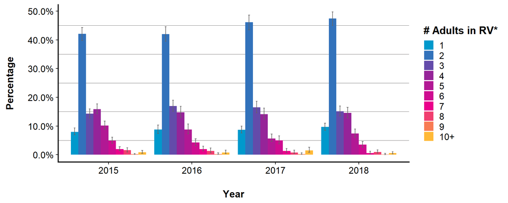

Error bars indicate the upper and lower bounds of the 95% confidence intervals.

* Data presented in the plot above and table below are for participants indicating RV/trailer use during Burning Man in a given year.

|  | 2015 Percent | 2015 MoE +/- % |  | 2016 Percent | 2016 MoE +/- % |  | 2017 Percent | 2017 MoE +/- % |  | 2018 Percent | 2018 MoE +/- % |
| --- | --- | --- | --- | --- | --- | --- | --- | --- | --- | --- | --- |
| 1 | 8.0 | 1.2 |  | 8.8 | 1.4 |  | 8.7 | 1.2 |  | 9.7 | 1.2 |
| 2 | 42.1 | 2.2 |  | 42.0 | 2.5 |  | 46.1 | 2.5 |  | 47.4 | 2.4 |
| 3 | 14.3 | 1.6 |  | 17.0 | 2.0 |  | 16.5 | 2.0 |  | 15.1 | 1.8 |
| 4 | 15.9 | 1.8 |  | 14.8 | 2.0 |  | 14.1 | 2.0 |  | 14.6 | 2.0 |
| 5 | 10.2 | 1.4 |  | 8.8 | 1.8 |  | 5.7 | 1.4 |  | 7.4 | 1.4 |
| 6 | 4.9 | 1.0 |  | 4.3 | 1.2 |  | 5.0 | 1.4 |  | 3.5 | 1.0 |
| 7 | 2.0 | 0.8 |  | 2.0 | 0.8 |  | 1.3 | 0.6 |  | 0.6 | 0.4 |
| 8 | 1.6 | 0.8 |  | 1.3 | 0.8 |  | 0.8 | 0.6 |  | 1.0 | 0.6 |
| 9 | 0.2 | 0.2 |  | 0.2 | 0.2 |  | 0.2 | 0.2 |  | 0.1 | 0.2 |
| 10+ | 0.9 | 0.4 |  | 0.8 | 0.6 |  | 1.5 | 0.8 |  | 0.6 | 0.4 |

**Next:** Life in BRC: Leave No Trace and On-Playa Power